# Social Network Analysis

Michael Liou

12/6/2021

# Visualizing Networks

- [ggraph](https://ggraph.data-imaginist.com/) - a nice interface for network data into ggplot
- gephi - has been around a while
- UCINET - windows only
- Pajek - very nice interface

# Sienna

## Introduction

Stands for Simulation Investigation for Empirical Network Analysis, named after the city in which the work for this started.

Program for statistical analysis of network data, with the focus on social networks. There’s some interesting context for this

The basic model fit

## Resources

- [Informational Website](https://www.stats.ox.ac.uk/~snijders/siena/) - the home website for the SIENNA Project. The website also contains many helpful example scripts and datasets.
- [Manual for R](https://www.stats.ox.ac.uk/~snijders/siena/RSiena_Manual.pdf#section.8) - This is the place to get started with SIENA modeling, with a longer, practical introduction to using their software.
- Duke 2018 Workshop Materials - There’s some powerpoints with details calculations of how each objective function and evaluation function actually plays out for change in the dyad.
  - [Links to all the resources and lectures](https://sites.duke.edu/dnac/training/) - the entire workshop materials listed on the website.

## Model Specification

See Section 5 of [Manual for R](https://www.stats.ox.ac.uk/~snijders/siena/RSiena_Manual.pdf#section.5)

There are 4 types of functions in the model specification:

1. Rate functions - how often do we get the opportunity to change around the specification?
2. Evaluation functions - determines the probability of changing their ties. Can be thought of evaluating “satisfaction” for each actor’s local environment, actors will change to increase their total satisfaction.
3. Creation function - probability of changes only in the creation of new ties.
4. Maintenance function - probability of changes only in the maintenance and termination of existing ties.

Most of the time we’re only using the first 2, rate and evaluation, with most of the focus on the evaluation function

## Meta Analysis in Rsienna

The idea is to fit SABM’s to each network, and combine the parameter estimates intelligently from all the studies. We could also consider combining the network into one large network and add structural zeros for nodes from different networks, this would also work, but apparently it’s very slow running as a large diagonal block matrix in RSienna.

## Examples

### PH819 Lab (single network, two timepoints)

```r
friend.data.w1 <- as.matrix(read.table("data/class5809.txt"))
friend.data.w2 <- as.matrix(read.table("data/class5809_t2.txt"))
attr5809<-read.table("data/attr5809.txt",header=TRUE,stringsAsFactors=FALSE)

for (i in 1:nrow(attr5809)) {if (attr5809[i,50] > 98) {friend.data.w2[i,]=9}}
friend.data.w1[friend.data.w1 %in% c(6,9)] <- NA
friend.data.w2[friend.data.w2 %in% c(6,9)] <- NA

alcfrq<-cbind(attr5809[,45],attr5809[,48])
alcfrq[alcfrq %in% c(4,5,6)] <- 4
alcfrq[alcfrq %in% c(99)] <- NA
```

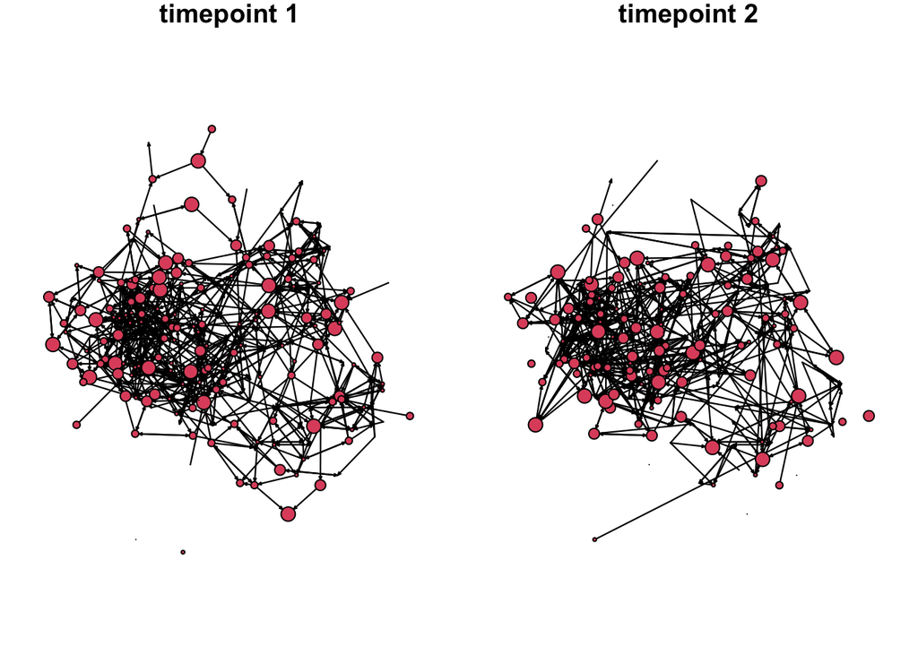

```r
# Visualize the networks that we're working with
par(mfrow = c(1, 2), oma = c(0, 0, 0, 0), mar = c(0, 0, 1, 0))

kcoord <- gplot.layout.fruchtermanreingold(friend.data.w1, layout.par = NULL)
gplot(friend.data.w1, coord = kcoord, main = "timepoint 1", vertex.cex = alcfrq[,1], object.scale = .005)
gplot(friend.data.w2, coord = kcoord, main = "timepoint 2", vertex.cex = alcfrq[,2], object.scale = .005)
```

```r
# create the network (response) and the behavior attributes for each timepoint
friendties <- sienaNet(array(c(friend.data.w1, friend.data.w2),
                             dim=c(nrow(attr5809), nrow(attr5809), 2)))
alcdrinkbeh <- sienaNet(alcfrq, type="behavior")

# create data covariates
ah_pvt <- coCovar(attr5809[,36]) # denotes constant Covariates
age <- coCovar(attr5809[,38])
male <- coCovar(attr5809[,40])
parentdrkfrq <- coCovar(attr5809[,53])
parentdrkfiv <- coCovar(attr5809[,54])
tobacco <- coCovar(attr5809[,56])
```

```r
# create the data object for siena
data5809 <- sienaDataCreate(friendties,
                            ah_pvt, age, male, parentdrkfrq,
                            parentdrkfiv,tobacco,alcdrinkbeh)
eff5809 <- getEffects(data5809)

# prints out a txtfile with more information
print01Report(data5809, modelname = 'class5809_init')
```

```r
# Fit the null model, and display the summary without covariance
# creates output file "class5809_run1.txt"
model5809 <- sienaModelCreate(useStdInits = FALSE,
                              projname = 'class5809_run1')
ans5809 <- siena07(model5809, data=data5809, effects=eff5809,
                   batch=FALSE, verbose=FALSE)
```

```r
ans5809 # display results from fitting
```

```
## Estimates, standard errors and convergence t-ratios
##
##                                           Estimate   Standard   Convergence
##                                                        Error      t-ratio
## Network Dynamics
##   1. rate basic rate parameter friendties  8.5465  ( 0.4487   )    0.0012
##   2. eval outdegree (density)             -2.7277  ( 0.0477   )    0.0135
##   3. eval reciprocity                      2.5998  ( 0.1139   )    0.0170
##
## Behavior Dynamics
##   4. rate rate alcdrinkbeh period 1        5.8028  ( 1.0476   )    0.0209
##   5. eval alcdrinkbeh linear shape        -0.3723  ( 0.0531   )   -0.0425
##   6. eval alcdrinkbeh quadratic shape      0.1574  ( 0.0346   )    0.0091
##
## Overall maximum convergence ratio:    0.0673
##
##
## Total of 2669 iteration steps.
```

```r
# Wald-style p-values can be calculated by

1 - pnorm(abs(ans5809$theta / ans5809$se))
```

```
## [1] 0.000000e+00 0.000000e+00 0.000000e+00 1.518737e-08 1.202927e-12
## [6] 2.674469e-06
```

### PH819 Lab Meta analysis (4 networks, 2 timepoints each)

There’s a massive amount of code for this, and we need to run SABM for all 4 models before we can actually do a meta analysis

```r
# Network 1: class 7
friend.data.w1 <- as.matrix(read.table("data/class7.txt"))
friend.data.w2 <- as.matrix(read.table("data/class7_t2.txt"))
attr7<-read.table("data/attr7.txt",header=TRUE,stringsAsFactors=FALSE)
for (i in 1:nrow(attr7)) {if (attr7[i,48] > 98) {friend.data.w2[i,]=9}}
friend.data.w1[friend.data.w1 %in% c(6,9)] <- NA
friend.data.w2[friend.data.w2 %in% c(6,9)] <- NA
alcdrinkbeh<-cbind(attr7[,45],attr7[,48])
alcdrinkbeh[alcdrinkbeh %in% c(99)] <- NA
friendties <- sienaNet(array(c(friend.data.w1,friend.data.w2),dim=c(nrow(attr7),nrow(attr7),2)))
alcdrinkbeh <- sienaNet(alcdrinkbeh,type="behavior")
ah_pvt <- coCovar(attr7[,36])
age <- coCovar(attr7[,38])
male <- coCovar(attr7[,40])
parentdrkfrq <- coCovar(attr7[,53])
tobacco <- coCovar(attr7[,56])
dataset.7 <- sienaDataCreate(friendties,ah_pvt,age,male,parentdrkfrq,tobacco,alcdrinkbeh)
effects.7 <- getEffects(dataset.7)
effectsDocumentation(effects.7)

effects.7 <- includeEffects(effects.7,transTrip,type="eval")
effects.7 <- includeEffects(effects.7,cycle3,type="eval")
effects.7 <- includeEffects(effects.7,simX,type="eval",interaction1="age") #age similarity
effects.7 <- includeEffects(effects.7,sameX,type="eval",interaction1="male") #same gender
effects.7 <- includeEffects(effects.7,simX,type="eval",interaction1="ah_pvt") #similar scholastic aptitude
effects.7 <- includeEffects(effects.7,simX,type="eval",interaction1="alcdrinkbeh") #similar alcoholic use
effects.7 <- includeEffects(effects.7,name="alcdrinkbeh",maxAlt,interaction1="friendties") #average exposure
# effects.7 <- includeEffects(effects.7,name="alcdrinkbeh",avRecAlt,interaction1="friendties") #average exposure
effects.7 <- includeEffects(effects.7,name="alcdrinkbeh",effFrom,type="eval",interaction1="age") #age effect
effects.7 <- includeEffects(effects.7,name="alcdrinkbeh",effFrom,type="eval",interaction1="parentdrkfrq") #parent drinking effect
effects.7 <- includeEffects(effects.7,name="alcdrinkbeh",effFrom,type="eval",interaction1="tobacco") #tobacco effect
effects.7 <- includeEffects(effects.7,name="alcdrinkbeh",effFrom,type="eval",interaction1="ah_pvt") #ah_pvt effect

modelall <- sienaModelCreate(useStdInits = FALSE, projname = 'AlcoholBehavior')

ans.7 <- siena07(modelall, data=dataset.7, effects=effects.7, batch=FALSE)
```

```r
# Network 2: class 5809
friend.data.w1 <- as.matrix(read.table("data/class5809.txt"))
friend.data.w2 <- as.matrix(read.table("data/class5809_t2.txt"))
attr5809<-read.table("data/attr5809.txt",header=TRUE,stringsAsFactors=FALSE)
for (i in 1:nrow(attr5809)) {if (attr5809[i,48] > 98) {friend.data.w2[i,]=9}}
friend.data.w1[friend.data.w1 %in% c(6,9)] <- NA
friend.data.w2[friend.data.w2 %in% c(6,9)] <- NA
alcdrinkbeh<-cbind(attr5809[,45],attr5809[,48])
alcdrinkbeh[alcdrinkbeh %in% c(99)] <- NA
friendties <- sienaNet(array(c(friend.data.w1,friend.data.w2),dim=c(nrow(attr5809),nrow(attr5809),2)))
alcdrinkbeh <- sienaNet(alcdrinkbeh,type="behavior")
ah_pvt <- coCovar(attr5809[,36])

age <- coCovar(attr5809[,38])
male <- coCovar(attr5809[,40])
parentdrkfrq <- coCovar(attr5809[,53])
tobacco <- coCovar(attr5809[,56])
dataset.5809 <- sienaDataCreate(friendties,ah_pvt,age,male,parentdrkfrq,tobacco,alcdrinkbeh)
effects.5809 <- getEffects(dataset.5809)

effects.5809 <- includeEffects(effects.5809,transTrip,type="eval")
effects.5809 <- includeEffects(effects.5809,cycle3,type="eval")
effects.5809 <- includeEffects(effects.5809,simX,type="eval",interaction1="age") #age similarity
effects.5809 <- includeEffects(effects.5809,sameX,type="eval",interaction1="male") #same gender
effects.5809 <- includeEffects(effects.5809,simX,type="eval",interaction1="ah_pvt") #similar scholastic aptitude
effects.5809 <- includeEffects(effects.5809,simX,type="eval",interaction1="alcdrinkbeh") #similar alcoholic use
effects.5809 <- includeEffects(effects.5809,name="alcdrinkbeh",maxAlt,interaction1="friendties") #average exposure
# effects.5809 <- includeEffects(effects.5809,name="alcdrinkbeh",avRecAlt,interaction1="friendties") #average exposure
effects.5809 <- includeEffects(effects.5809,name="alcdrinkbeh",effFrom,type="eval",interaction1="age") #age effect
effects.5809 <- includeEffects(effects.5809,name="alcdrinkbeh",effFrom,type="eval",interaction1="parentdrkfrq") #parent drinking effect
effects.5809 <- includeEffects(effects.5809,name="alcdrinkbeh",effFrom,type="eval",interaction1="tobacco") #tobacco effect
effects.5809 <- includeEffects(effects.5809,name="alcdrinkbeh",effFrom,type="eval",interaction1="ah_pvt") #ah_pvt effect

modelall <- sienaModelCreate(useStdInits = FALSE, projname = 'AlcoholBehavior')

ans.5809 <- siena07(modelall, data=dataset.5809, effects=effects.5809, batch=FALSE)
```

```r
# Network 3: class 8
friend.data.w1 <- as.matrix(read.table("data/class8.txt"))
friend.data.w2 <- as.matrix(read.table("data/class8_t2.txt"))
attr8<-read.table("data/attr8.txt",header=TRUE,stringsAsFactors=FALSE)
for (i in 1:nrow(attr8)) {if (attr8[i,48] > 98) {friend.data.w2[i,]=9}}
friend.data.w1[friend.data.w1 %in% c(6,9)] <- NA
friend.data.w2[friend.data.w2 %in% c(6,9)] <- NA

alcdrinkbeh<-cbind(attr8[,45],attr8[,48])
alcdrinkbeh[alcdrinkbeh %in% c(99)] <- NA
friendties <- sienaNet(array(c(friend.data.w1,friend.data.w2),dim=c(nrow(attr8),nrow(attr8),2)))
alcdrinkbeh <- sienaNet(alcdrinkbeh,type="behavior")
ah_pvt <- coCovar(attr8[,36])
age <- coCovar(attr8[,38])
male <- coCovar(attr8[,40])
parentdrkfrq <- coCovar(attr8[,53])
tobacco <- coCovar(attr8[,56])
dataset.8 <- sienaDataCreate(friendties,ah_pvt,age,male,parentdrkfrq,tobacco,alcdrinkbeh)
effects.8 <- getEffects(dataset.8)
effects.8 <- includeEffects(effects.8,transTrip,type="eval")
effects.8 <- includeEffects(effects.8,cycle3,type="eval")
effects.8 <- includeEffects(effects.8,simX,type="eval",interaction1="age") #age similarity
effects.8 <- includeEffects(effects.8,sameX,type="eval",interaction1="male") #same gender
effects.8 <- includeEffects(effects.8,simX,type="eval",interaction1="ah_pvt") #similar scholastic aptitude
effects.8 <- includeEffects(effects.8,simX,type="eval",interaction1="alcdrinkbeh") #similar alcoholic use
effects.8 <- includeEffects(effects.8,name="alcdrinkbeh",maxAlt,interaction1="friendties") #average exposure
# effects.8 <- includeEffects(effects.8,name="alcdrinkbeh",avRecAlt,interaction1="friendties") #average exposure
effects.8 <- includeEffects(effects.8,name="alcdrinkbeh",effFrom,type="eval",interaction1="age") #age effect
effects.8 <- includeEffects(effects.8,name="alcdrinkbeh",effFrom,type="eval",interaction1="parentdrkfrq") #parent drinking effect
effects.8 <- includeEffects(effects.8,name="alcdrinkbeh",effFrom,type="eval",interaction1="tobacco") #tobacco effect
effects.8 <- includeEffects(effects.8,name="alcdrinkbeh",effFrom,type="eval",interaction1="ah_pvt") #ah_pvt effect

modelall <- sienaModelCreate(useStdInits = FALSE, projname = 'AlcoholBehavior')

ans.8 <- siena07(modelall, data=dataset.8, effects=effects.8, batch=FALSE)
```

```r
# Network 4: class 88
friend.data.w1 <- as.matrix(read.table("data/class88.txt"))
friend.data.w2 <- as.matrix(read.table("data/class88_t2.txt"))
attr88<-read.table("data/attr88.txt",header=TRUE,stringsAsFactors=FALSE)
for (i in 1:nrow(attr88)) {if (attr88[i,48] > 98) {friend.data.w2[i,]=9}}
friend.data.w1[friend.data.w1 %in% c(6,9)] <- NA
friend.data.w2[friend.data.w2 %in% c(6,9)] <- NA
alcdrinkbeh<-cbind(attr88[,45],attr88[,48])
alcdrinkbeh[alcdrinkbeh %in% c(99)] <- NA
friendties <- sienaNet(array(c(friend.data.w1,friend.data.w2),dim=c(nrow(attr88),nrow(attr88),2)))
alcdrinkbeh <- sienaNet(alcdrinkbeh,type="behavior")
ah_pvt <- coCovar(attr88[,36])
age <- coCovar(attr88[,38])
male <- coCovar(attr88[,40])
parentdrkfrq <- coCovar(attr88[,53])
tobacco <- coCovar(attr88[,56])
dataset.88 <- sienaDataCreate(friendties,ah_pvt,age,male,parentdrkfrq,tobacco,alcdrinkbeh)
effects.88 <- getEffects(dataset.88)

effects.88 <- includeEffects(effects.88,transTrip,type="eval")
effects.88 <- includeEffects(effects.88,cycle3,type="eval")
effects.88 <- includeEffects(effects.88,simX,type="eval",interaction1="age") #age similarity
effects.88 <- includeEffects(effects.88,sameX,type="eval",interaction1="male") #same gender
effects.88 <- includeEffects(effects.88,simX,type="eval",interaction1="ah_pvt") #similar scholastic aptitude
effects.88 <- includeEffects(effects.88,simX,type="eval",interaction1="alcdrinkbeh") #similar alcoholic use
effects.88 <- includeEffects(effects.88,name="alcdrinkbeh",maxAlt,interaction1="friendties") #average exposure
# effects.88 <- includeEffects(effects.88,name="alcdrinkbeh",avRecAlt,interaction1="friendties") #average exposure
effects.88 <- includeEffects(effects.88,name="alcdrinkbeh",effFrom,type="eval",interaction1="age") #age effect
effects.88 <- includeEffects(effects.88,name="alcdrinkbeh",effFrom,type="eval",interaction1="parentdrkfrq") #parent drinking effect
effects.88 <- includeEffects(effects.88,name="alcdrinkbeh",effFrom,type="eval",interaction1="tobacco") #tobacco effect
effects.88 <- includeEffects(effects.88,name="alcdrinkbeh",effFrom,type="eval",interaction1="ah_pvt") #ah_pvt effect

modelall <- sienaModelCreate(useStdInits = FALSE, projname = 'AlcoholBehavior')

ans.88 <- siena07(modelall, data=dataset.88, effects=effects.88, batch=FALSE)
```

the actual meta analysis is done by the function `siena08()`, based on Siena fits.

- Must have the same covariates fit in the networks. The output of the file is pretty self explanatory.
- There’s an automatic warning/filtering if the standard error of any of the variable estimates is >5 because this is a sign of instability, and need to model the networks again.
- If you have fit warning, the advice is to check the output simulations and goodness-of-fit parameters to make sure we have a good fit

```r
meta <- siena08(ans.5809, ans.88, ans.7, ans.8)
```

```
## Warning in iwlsm.default(x, y, weights, method = method, wt.method =
## wt.method, : iwlsm failed to converge in 20 steps
```

```r
summary(meta)
```

```
## ================================= SIENA08 ================================================
## Multilevel use of Siena algorithms according to Snijders & Baerveldt (2003) with extension
## ==========================================================================================
##
## Number of projects in the list is 4.
## The names of these projects are :
## project1: <AlcoholBehavior(ans.5809)>
## project2: <AlcoholBehavior(ans.88)>
## project3: <AlcoholBehavior(ans.7)>
## project4: <AlcoholBehavior(ans.8)>
##
## Options for running Siena08:
## -> Parameters are excluded from the meta-analysis when their standard
##    error exceeds an upper bound of 5.
## -> Extra output requested
##
## The RSiena Version of the first fit object is 1.3.0.1.
##
## Object <AlcoholBehavior(ans.5809)> contains estimates of 17 parameters.
## The number of valid score tests found was 17.
## Object <AlcoholBehavior(ans.7)> contains estimates of 17 parameters.
## The number of valid score tests found was 17.
## Object <AlcoholBehavior(ans.8)> contains estimates of 17 parameters.
## The number of valid score tests found was 17.
## Object <AlcoholBehavior(ans.88)> contains estimates of 17 parameters.
## The number of valid score tests found was 17.
##
## A total of 17 parameters in 4 projects :
##  1. rate : basic rate parameter friendties
##  2. eval : outdegree (density)
##  3. eval : reciprocity
##  4. eval : transitive triplets
##  5. eval : 3-cycles
##  6. eval : ah_pvt similarity
##  7. eval : age similarity
##  8. eval : same male
##  9. eval : alcdrinkbeh similarity
## 10. rate : rate alcdrinkbeh period 1
## 11. eval : alcdrinkbeh linear shape
## 12. eval : alcdrinkbeh quadratic shape
```

[output cut: 821 more lines]

[output not shown]

# Exponential Random Graphs

## Lazega example

From Statistical Analysis of Networks with R

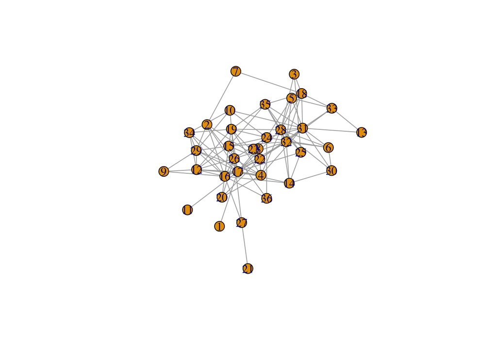

```r
# igraph example
data(lazega)
plot(lazega, layout = layout_with_kk, vertex.label = V(lazega),
     vertex.size = 10)
```

```r
# making statnet version of network data
A <- get.adjacency(lazega)
v.attrs <- get.data.frame(lazega, what= "vertices")
lazega.s <- as.network(as.matrix(A), directed = FALSE)
network::set.vertex.attribute(lazega.s, "office", v.attrs$Office)
network::set.vertex.attribute(lazega.s, "practice", v.attrs$Practice)
network::set.vertex.attribute(lazega.s, "gender", v.attrs$Gender)
network::set.vertex.attribute(lazega.s, "seniority", v.attrs$Seniority)
```

```r
# summary statistics
## Degrees
ergm_deg <- formula(lazega.s ~ degree(1:8) + triangles)
summary(ergm_deg)
```

```
##  degree1  degree2  degree3  degree4  degree5  degree6  degree7  degree8
##        3        2        4        2        4        4        1        1
## triangle
##      120
```

```r
degree_distribution(lazega) * vcount(lazega)
```

```
##  [1] 2 3 2 4 2 4 4 1 1 5 1 1 2 3 0 1
```

```r
degreedist(lazega.s) # statnet
```

```
##  degree0  degree1  degree2  degree3  degree4  degree5  degree6  degree7
##        2        3        2        4        2        4        4        1
##  degree8  degree9 degree10 degree11 degree12 degree13 degree15
##        1        5        1        1        2        3        1
```

```r
# mixing matrix - how many ties are between each for each attribute
mixingmatrix(lazega.s, "gender")
```

```
##    1  2
## 1 98 16
## 2 16  1
```

```
## Note:  Marginal totals can be misleading for undirected mixing matrices.
```

```r
# Bernoulli ERGM
ergm_bern_form <- formula(lazega.s ~ edges)
summary(ergm_bern_form)
```

```
## edges
##   115
```

```r
ergm_bern <- ergm(ergm_bern_form)
summary(ergm_bern)
```

```
## Call:
## ergm(formula = ergm_bern_form)
##
## Maximum Likelihood Results:
##
##       Estimate Std. Error MCMC % z value Pr(>|z|)
## edges  -1.4992     0.1031      0  -14.54   <1e-04 ***
## ---
## Signif. codes:  0 '***' 0.001 '**' 0.01 '*' 0.05 '.' 0.1 ' ' 1
##
##      Null Deviance: 873.4  on 630  degrees of freedom
##  Residual Deviance: 598.8  on 629  degrees of freedom
##
## AIC: 600.8  BIC: 605.2  (Smaller is better. MC Std. Err. = 0)
```

```r
exp(-1.499) / (1 + exp(-1.499 )) # this is also the density of the network
```

```
## [1] 0.1825747
```

The interpretation of this “edges” network means, that if we were to try to estimate the probability of the existence of an edge by just the number of edges in the model, we should expect a uniform distribution of the edges

```
##  degree3  degree4  degree5  degree6  degree7  degree8  degree9 degree10
##        2        8        1        5        6        9        1        2
## degree11
##        2
```

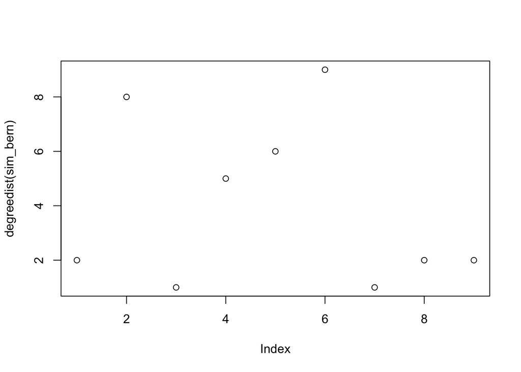

```r
# Simulating from ergm
sim_bern <- simulate(ergm_bern, burnin = 1e+6, seed = 9)
plot(degreedist(sim_bern))
```

```r
degreedist(lazega.s)
```

```
##  degree0  degree1  degree2  degree3  degree4  degree5  degree6  degree7
##        2        3        2        4        2        4        4        1
##  degree8  degree9 degree10 degree11 degree12 degree13 degree15
##        1        5        1        1        2        3        1
```

```r
# simulate with triangles
ergm_tri_form <- formula(lazega.s ~ triangle)
summary(ergm_tri_form)
```

```
## triangle
##      120
```

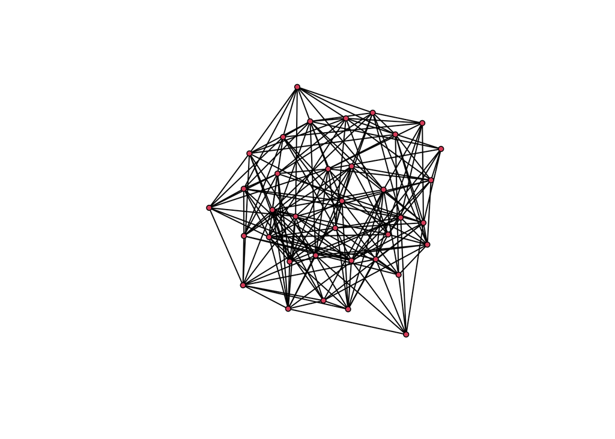

```r
ergm_tri <- ergm(ergm_tri_form)
sim_tri <- simulate(ergm_tri)
plot(sim_tri)
```

```r
summary(ergm_tri)
```

```
## Call:
## ergm(formula = ergm_tri_form)
##
## Monte Carlo Maximum Likelihood Results:
##
##          Estimate Std. Error MCMC % z value Pr(>|z|)
## triangle -0.38408    0.05356      0  -7.171   <1e-04 ***
## ---
## Signif. codes:  0 '***' 0.001 '**' 0.01 '*' 0.05 '.' 0.1 ' ' 1
##
##      Null Deviance: 873.4  on 630  degrees of freedom
##  Residual Deviance: 734.7  on 629  degrees of freedom
##
## AIC: 736.7  BIC: 741.2  (Smaller is better. MC Std. Err. = 1.809)
```

```r
exp(-0.38937) / (1 + exp(-0.38937)) # p = .403
```

```
## [1] 0.403869
```

.403 should loosely translate to the density of triangles, but I don’t know how.

```r
# Complex with k stars
ergm_complex <- formula(lazega.s ~ edges + kstar(2) + kstar(3) + triangle)
summary(ergm_complex)
```

```
##    edges   kstar2   kstar3 triangle
##      115      926     2681      120
```

```r
# alternating kstar statistic
ergm_geometric <- formula(lazega.s ~ edges + gwesp(1, fixed = TRUE))
summary(ergm_geometric)
```

```
##         edges gwesp.fixed.1
##      115.0000      213.1753
```

```r
ergm_lazega <- formula(lazega.s ~ edges +
                         gwesp(log(3), fixed = TRUE) +
                         nodemain("seniority") +
                         nodemain("practice") +
                         match("practice") + # dyads that link same practice
                         match("gender") + # dyads that link same gender
                         match("office"))
summary(ergm_lazega)
```

```
##                        edges gwesp.fixed.1.09861228866811
##                     115.0000                     222.9108
##            nodecov.seniority             nodecov.practice
##                    4687.0000                     359.0000
##           nodematch.practice             nodematch.gender
##                      72.0000                      99.0000
##             nodematch.office
##                      85.0000
```

Types of structural components

- “geometrically weighted degree count”
- “Alternating sums of k-triangles”
- “Alternating k-star statistic”

```r
# ERGM fitting
ergm_lazega_fit <- ergm(ergm_lazega)
anova(ergm_lazega_fit) # overall fit based on deviance statistic i guess
```

```
## Analysis of Variance Table
##
## Model 1: lazega.s ~ edges + gwesp(log(3), fixed = TRUE) + nodemain("seniority") +
##     nodemain("practice") + match("practice") + match("gender") +
##     match("office")
##          Df Deviance Resid. Df Resid. Dev Pr(>|Chisq|)
## NULL                       630     873.37
## Model 1:  7   414.21       623     459.15    < 2.2e-16 ***
## ---
## Signif. codes:  0 '***' 0.001 '**' 0.01 '*' 0.05 '.' 0.1 ' ' 1
```

```r
summary(ergm_lazega_fit)
```

```
## Call:
## ergm(formula = ergm_lazega)
##
## Monte Carlo Maximum Likelihood Results:
##
##                               Estimate Std. Error MCMC % z value Pr(>|z|)
## edges                        -6.986707   0.702364      0  -9.947  < 1e-04 ***
## gwesp.fixed.1.09861228866811  0.593179   0.090664      0   6.543  < 1e-04 ***
## nodecov.seniority             0.024421   0.006398      0   3.817 0.000135 ***
## nodecov.practice              0.394574   0.111854      0   3.528 0.000419 ***
## nodematch.practice            0.766302   0.201292      0   3.807 0.000141 ***
## nodematch.gender              0.718759   0.253477      0   2.836 0.004574 **
## nodematch.office              1.160059   0.194185      0   5.974  < 1e-04 ***
## ---
## Signif. codes:  0 '***' 0.001 '**' 0.01 '*' 0.05 '.' 0.1 ' ' 1
##
##      Null Deviance: 873.4  on 630  degrees of freedom
##  Residual Deviance: 459.2  on 623  degrees of freedom
##
## AIC: 473.2  BIC: 504.3  (Smaller is better. MC Std. Err. = 0.247)
```

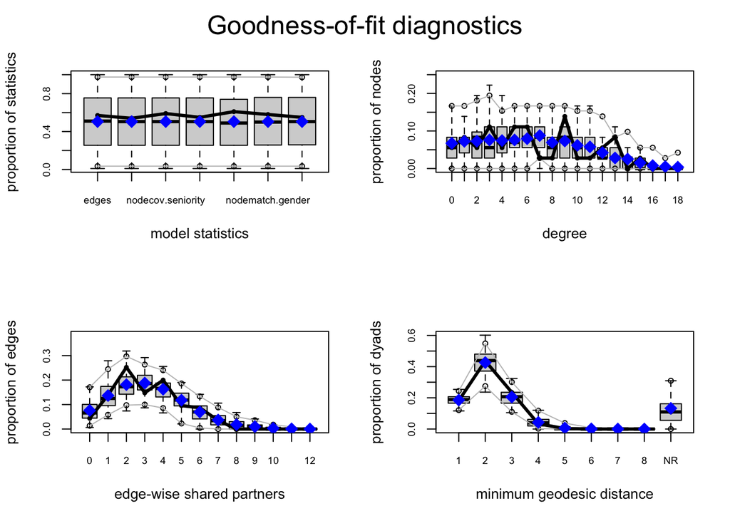

```r
# goodness of fit
ergm_lazega_gof <- gof(ergm_lazega_fit)
par(mfrow = c(2, 2))
plot(ergm_lazega_gof)
```

The way goodness of fit is currently conducted is by generating a bunch of network statistics and seeing if they fit the simulated distribution.

# Linear Regression w/ Matrices

Section follows [Dai Shizuka’s Intro to MRQAP](https://dshizuka.github.io/networkanalysis/07_mrqap.html)

```r
# Generate random matrices
set.seed(2)
m1=rgraph(10, m=1, tprob=0.5, mode="graph")
m2=rgraph(10, m=1, tprob=0.5, mode="graph")
m3=rgraph(10, m=1, tprob=0.5, mode="graph")
```

```r
mod_net <- netlm(m1, m2 + m3, mode = "graph", nullhyp = "qap", test.statistic = "t-value")

summary(mod_net)
```

```
##
## OLS Network Model
##
## Residuals:
##         0%        25%        50%        75%       100%
## -0.6245211 -0.5383142  0.3754789  0.4616858  0.5478927
##
## Coefficients:
##             Estimate   Pr(<=b) Pr(>=b) Pr(>=|b|)
## (intercept)  0.6245211 1.00    0.00    0.000
## x1          -0.0862069 0.19    0.82    0.361
##
## Residual standard error: 0.5044 on 43 degrees of freedom
## Multiple R-squared: 0.01552  Adjusted R-squared: -0.007378
## F-statistic: 0.6778 on 1 and 43 degrees of freedom, p-value: 0.4149
##
##
## Test Diagnostics:
##
##  Null Hypothesis: qap
##  Replications: 1000
##  Coefficient Distribution Summary:
##
##        (intercept)         x1
## Min     -5.082e-01 -3.177e+00
## 1stQ     1.708e+00 -8.233e-01
## Median   2.298e+00  5.561e-17
## Mean     2.350e+00  1.370e-02
## 3rdQ     2.935e+00  8.233e-01
## Max      5.194e+00  5.220e+00
```

```r
# recreating netlm
y <- m1[upper.tri(m1)]
x <- (m2+m3)[upper.tri(m1)]

summary(lm(y~x))
```

```
##
## Call:
## lm(formula = y ~ x)
##
## Residuals:
##     Min      1Q  Median      3Q     Max
## -0.6245 -0.5383  0.3755  0.4617  0.5479
##
## Coefficients:
##             Estimate Std. Error t value Pr(>|t|)
## (Intercept)  0.62452    0.11256   5.548 1.65e-06 ***
## x           -0.08621    0.10471  -0.823    0.415
## ---
## Signif. codes:  0 '***' 0.001 '**' 0.01 '*' 0.05 '.' 0.1 ' ' 1
##
## Residual standard error: 0.5044 on 43 degrees of freedom
## Multiple R-squared:  0.01552,    Adjusted R-squared:  -0.007378
## F-statistic: 0.6778 on 1 and 43 DF,  p-value: 0.4149
```

It seems that `netlm` is simply vectorizing the upper triangle of the matrix and running lm. In this case, they have 1 response and 1 covariate matrix. There is some additional output for the coefficient distribution.

```r
mrqap.dsp(m1~m2+m3, directed = "undirected", randomisations = 10000)
```

```
## MRQAP with Double-Semi-Partialing (DSP)
##
## Formula:  m1 ~ m2 + m3
##
## Coefficients:
##           Estimate    P(β>=r) P(β<=r) P(|β|<=|r|)
## intercept  0.62001925 0.9983  0.0017  0.0017
## m2         0.05813282 0.6343  0.3657  0.7110
## m3        -0.23561116 0.0664  0.9336  0.1506
##
## Residual standard error: 0.5002 on 42 degrees of freedom
## F-statistic: 1.202 on 2 and 42 degrees of freedom, p-value: 0.3106
## Multiple R-squared: 0.05416  Adjusted R-squared: 0.00912
## AIC: -40.77726
```

```r
# same thing, but with additional regressor.
y <- m1[upper.tri(m1)]
x1 <- m2[upper.tri(m2)]
x2 <- m3[upper.tri(m3)]

manual_mrqap <- lm(y~x1+x2)

summary(manual_mrqap)
```

```
##
## Call:
## lm(formula = y ~ x1 + x2)
##
## Residuals:
##     Min      1Q  Median      3Q     Max
## -0.6782 -0.4425  0.3219  0.3800  0.6156
##
## Coefficients:
##             Estimate Std. Error t value Pr(>|t|)
## (Intercept)  0.62002    0.11169   5.551 1.75e-06 ***
## x1           0.05813    0.15142   0.384    0.703
## x2          -0.23561    0.15425  -1.527    0.134
## ---
## Signif. codes:  0 '***' 0.001 '**' 0.01 '*' 0.05 '.' 0.1 ' ' 1
##
## Residual standard error: 0.5002 on 42 degrees of freedom
## Multiple R-squared:  0.05416,    Adjusted R-squared:  0.00912
## F-statistic: 1.202 on 2 and 42 DF,  p-value: 0.3106
```

For the additional “testing of null hypothesis” version, see the paper references, but it involves first regressing on other covariates to “take out the effect”, Now we use the residuals in place of the original covariate and shuffle them for the permutation test. It’s unclear that there is any structure to the permutations.

```r
# first pval for x1
x1_resid <- lm(x1~x2)$residuals

set.seed(1)
num_random <- 10000
betas <- vector(mode = "numeric", length = num_random)
for (i in 1:num_random) {
  x1_resid_shuf <- sample(x1_resid, length(x1_resid))
  betas[i] <- lm(y~x1_resid_shuf + x2)$coef["x1_resid_shuf"]
}

mean(betas <= 0.05813)
```

```
## [1] 0.6494
```

```r
# second pval for x2
x2_resid <- lm(x2~x1)$residuals
y2_resid <- lm(y~x1)$residuals


lm(y ~ x1 + x2_resid) # beta coefficient is the same
```

```
##
## Call:
## lm(formula = y ~ x1 + x2_resid)
##
## Coefficients:
## (Intercept)           x1     x2_resid
##     0.53846      0.04049     -0.23561
```

```r
# # lm(y2_resid ~ x2_resid) # beta coefficient is the same
# lm(y~x1+x2) # beta coef in original.

set.seed(1)
num_random <- 10000
betas <- vector(mode = "numeric", length = num_random)
for (i in 1:num_random) {
  x2_resid_shuf <- sample(x2_resid, length(x2_resid))
  betas[i] <- lm(y~x1 + x2_resid_shuf)$coef["x2_resid_shuf"]
}
mean(betas <= -0.23561)
```

```
## [1] 0.0665
```

## Resources

- [Intro to Network Regression](https://dshizuka.github.io/networkanalysis/07_mrqap.html)

## QAP with correlation

Match results from “QAP Partialling as a test of spuriousness, Krackhardt (1987)”.

```r
m1 <- matrix(c(0, 1, 0, 0, 0,
               1, 0, 1, 0, 0,
               0, 1, 0, 1, 1,
               0, 0, 1, 0, 1,
               0, 0, 1, 1, 0), nrow = 5, byrow = T)
m2 <- matrix(c(0, 0, 1, 1, 1,
               0, 0, 0, 1, 1,
               1, 0, 0, 0, 1,
               1, 1, 0, 0, 0,
               1, 1, 1, 0, 0), nrow = 5, byrow = T)

cor(c(m1[upper.tri(m1)]), c(m2[upper.tri(m2)])) # matches paper
```

```
## [1] -0.8164966
```

# Permuting matrices

```r
# pmatrix from Matrix package, creates the permutation matrix based on a vector
(mm <- round(array(rnorm(3 * 3), c(3, 3)), 2))
```

```
##       [,1]  [,2]  [,3]
## [1,] -0.04  1.19  0.46
## [2,]  0.05  0.94  0.48
## [3,] -0.73 -0.59 -1.37
```

```r
(pm1 <- as(as.integer(c(2,3,1)), "pMatrix"))
```

```
## 3 x 3 sparse Matrix of class "pMatrix"
##
## [1,] . | .
## [2,] . . |
## [3,] | . .
```

```r
mm %*% pm1 # permute cols
```

```
##       [,1]  [,2]  [,3]
## [1,]  0.46 -0.04  1.19
## [2,]  0.48  0.05  0.94
## [3,] -1.37 -0.73 -0.59
```

```r
pm1 %*% mm # permute rows
```

```
##       [,1]  [,2]  [,3]
## [1,]  0.05  0.94  0.48
## [2,] -0.73 -0.59 -1.37
## [3,] -0.04  1.19  0.46
```

```r
mm[c(2,3,1), c(2, 3, 1)] # permute both row & col
```

```
##       [,1]  [,2]  [,3]
## [1,]  0.94  0.48  0.05
## [2,] -0.59 -1.37 -0.73
## [3,]  1.19  0.46 -0.04
```

# Network Block Models

Analagous to classic mixture models, and used to fit stochastic block models

$$\begin{aligned}
\mathbb{P}_\theta (Y = y) = \frac{1}{\kappa}\exp \left\{\sum_{q,r} \theta_{qr}L_{qr}(y)\right\}
\end{aligned}$$
where $L_{qr}(y)$ is the number of edges in the observed graph $y$ connecting pairs of vertices of classes between $q$ and $r$.

Algorithmically, the EM algorithm is a natural choice here.

Unfortunately, couldn’t get mixer to work because it errored out in installation.

# Latent Network Models

Loosely speaking, latent network models extract the eigenspace of relational data, essentially the eigen decomposition of the symmetric adjacency matrix. We follow Kolacyzk’s statistical analysis of network data in this section.

```r
set.seed(42) # for mcmc sampling
laz_A <- get.adjacency(lazega, sparse = FALSE)
```

```r
# base fit
lazega_leig_fit1 <- eigenmodel_mcmc(laz_A, R = 2, S = 11000, burn = 10000)
```

[output not shown]

```r
# same practice regressor
v_attr_df <- get.data.frame(lazega, what = "vertices")
same_prac_op <- v_attr_df$Practice %o% v_attr_df$Practice # outer product of all ties
# possible values are 1:3, so squared values are equality,
same_prac <- matrix(as.numeric(same_prac_op %in% c(1, 4, 9)), 36, 36)
# regressors into array
leig_X <- array(same_prac, dim = c(36, 36, 1))

# model w/ practice as regressor
lazega_leig_fit2 <- eigenmodel_mcmc(laz_A, leig_X, R = 2, S = 11000, burn = 1000)
```

[output not shown]

```r
# same office - create regression matrix
same_off_op <- v_attr_df$Office %o% v_attr_df$Office
same_off <- matrix(as.numeric(same_off_op %in% c(1, 4, 9)), 36, 36)
same_off <- array(same_off, dim = c(36, 36, 1))
leig_X <- array(same_off, dim = c(36, 36, 1))

lazega_leig_fit3 <- eigenmodel_mcmc(laz_A, leig_X, R = 2, S = 3000, burn = 5000)
```

[output not shown]

Below are the 3 latent variable spaces based on

1. base regression
2. same practice
3. same office

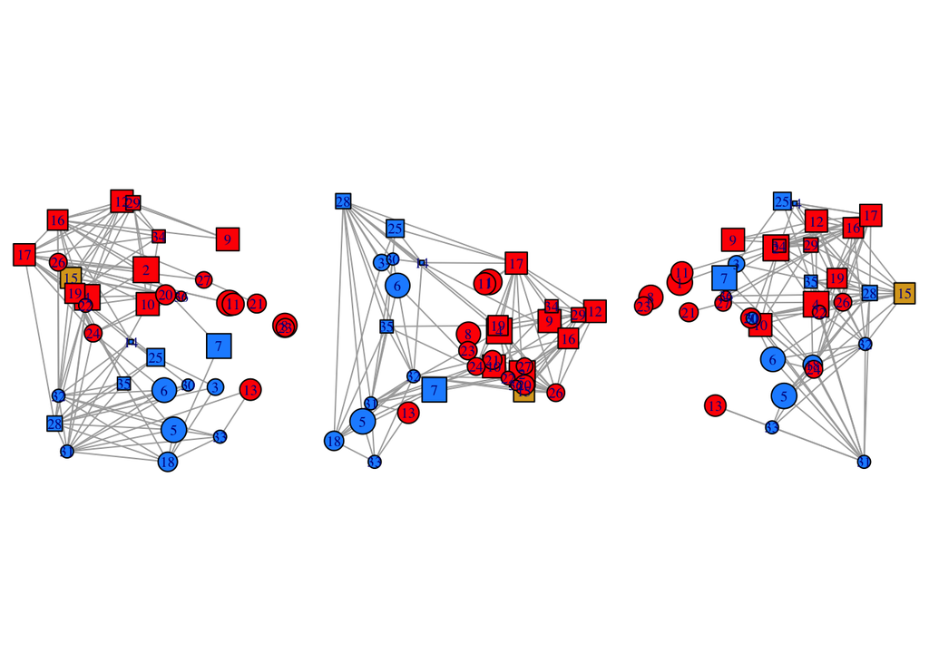

```r
par(mfrow = c(1, 3), oma = c(0, 0, 0, 0), mar = c(0, 0, 0, 0))
plot(lazega, layout = leig_lat_1,
     vertex.color = v_colors,
     vertex.shape = v_shapes,
     vertex.size = v_size,
     vertex.label = v_label)
plot(lazega, layout = leig_lat_2,
     vertex.color = v_colors,
     vertex.shape = v_shapes,
     vertex.size = v_size,
     vertex.label = v_label)
plot(lazega, layout = leig_lat_3,
     vertex.color = v_colors,
     vertex.shape = v_shapes,
     vertex.size = v_size,
     vertex.label = v_label)
```